# Prediction of College Tuition Rates Using Machine Learning Regression Models and Non-Financial Data

### Andrew Smith, May 2nd, 2023

## Introduction

This project attempts to relate the statistical figures of a university in the United States with its out-of-state tuition cost per student. Linear regression models will be created to determine which features of a university correlate the highest with increasing tuition costs, and overall, whether or not the cost of tuition can be accruately measured given only non-financial statistics.

The data is gathered from 777 unique universities across the United States and is shown below [1].

```python
import numpy as np
from scipy.stats import zscore
from numpy.linalg import norm

import pandas as pd
import seaborn as sns

import matplotlib.pyplot as plt
from matplotlib.pyplot import figure

from sklearn.pipeline import make_pipeline
from sklearn.preprocessing import StandardScaler

from sklearn.model_selection import train_test_split
from sklearn.model_selection import KFold, StratifiedKFold
from sklearn.model_selection import cross_validate, validation_curve

from sklearn.linear_model import LinearRegression
from sklearn.linear_model import Ridge
from sklearn.linear_model import Lasso
from sklearn.neighbors import KNeighborsRegressor
```

```python
colleges_raw = pd.read_csv('College_Data.csv', index_col=0) # load dataset, index by school
colleges_raw.head(5)
```

|  | Private | Apps | Accept | Enroll | Top10perc | Top25perc | F.Undergrad | P.Undergrad | Outstate | Room.Board | Books | Personal | PhD | Terminal | S.F.Ratio | perc.alumni | Expend | Grad.Rate |
| --- | --- | --- | --- | --- | --- | --- | --- | --- | --- | --- | --- | --- | --- | --- | --- | --- | --- | --- |
| Abilene Christian University | Yes | 1660 | 1232 | 721 | 23 | 52 | 2885 | 537 | 7440 | 3300 | 450 | 2200 | 70 | 78 | 18.1 | 12 | 7041 | 60 |
| Adelphi University | Yes | 2186 | 1924 | 512 | 16 | 29 | 2683 | 1227 | 12280 | 6450 | 750 | 1500 | 29 | 30 | 12.2 | 16 | 10527 | 56 |
| Adrian College | Yes | 1428 | 1097 | 336 | 22 | 50 | 1036 | 99 | 11250 | 3750 | 400 | 1165 | 53 | 66 | 12.9 | 30 | 8735 | 54 |
| Agnes Scott College | Yes | 417 | 349 | 137 | 60 | 89 | 510 | 63 | 12960 | 5450 | 450 | 875 | 92 | 97 | 7.7 | 37 | 19016 | 59 |
| Alaska Pacific University | Yes | 193 | 146 | 55 | 16 | 44 | 249 | 869 | 7560 | 4120 | 800 | 1500 | 76 | 72 | 11.9 | 2 | 10922 | 15 |

For example, data is presented below for the University of Delaware (go blue hens!).

```python
udel = colleges_raw.loc[['University of Delaware']]
udel
```

|  | Private | Apps | Accept | Enroll | Top10perc | Top25perc | F.Undergrad | P.Undergrad | Outstate | Room.Board | Books | Personal | PhD | Terminal | S.F.Ratio | perc.alumni | Expend | Grad.Rate |
| --- | --- | --- | --- | --- | --- | --- | --- | --- | --- | --- | --- | --- | --- | --- | --- | --- | --- | --- |
| University of Delaware | Yes | 14446 | 10516 | 3252 | 22 | 57 | 14130 | 4522 | 10220 | 4230 | 530 | 1300 | 82 | 87 | 18.3 | 15 | 10650 | 75 |

Each of the columns of the dataset are described below.

- Private: Boolean argument for whether an institution is private (Yes) or public (No)
- Apps: Number of applications received in the given time period
- Accept: Number of students accepted
- Enroll: Number of incoming students enrolled
- Top10perc: Percentage of new students who were in the top 10% of their high school class
- Top25perc: Percentage of new students who were in the top 25% of their high school class
- F.Undergrad: Number of fulltime undergraduate students
- P.Undergrad: Number of parttime undergraduate students
- Outstate: Total out-of-state tuition cost per semester (all in USD)
- Room.Board: Cost of combined room & board per semester
- Books: Estimated cost of books per student per semester
- Personal: Estimated personal spending per student
- PhD: Percentage of faculty with Ph.D. degrees
- Terminal: Percentage of faculty with with terminal degrees
- S.F.Ratio: Ratio of the number of students to the number of faculty
- perc.alumni: Percentage of alumni who donate to the university
- Expend: Instructional expenditure per student
- Grad.Rate: Graduation rate of student body

### Pre-Processing

The data can be pre-processed to create the desired feature and label matrices. The columns are first renammed for clarity then converted to numerical values when possible.

```python
# Clean data
colleges = colleges_raw # copy data
colleges = pd.get_dummies(colleges, columns = ['Private'], drop_first = True) # convert private to dummy

# Rename columns
colleges = colleges.rename(columns={"Top10perc" : "Top10pct", "Top25perc" : "Top25pct", "F.Undergrad" : "UndergradF", "P.Undergrad" : "UndergradP", "PhD" : "PhDpct", "Terminal" : "TerPct", "S.F.Ratio" : "SFratio", "Grad.Rate" : "GradRate", "Private_Yes" : "Private", "Room.Board" : "Housing", "perc.alumni" : "AlumniPct"})

colleges.head(5)
```

|  | Apps | Accept | Enroll | Top10pct | Top25pct | UndergradF | UndergradP | Outstate | Housing | Books | Personal | PhDpct | TerPct | SFratio | AlumniPct | Expend | GradRate | Private |
| --- | --- | --- | --- | --- | --- | --- | --- | --- | --- | --- | --- | --- | --- | --- | --- | --- | --- | --- |
| Abilene Christian University | 1660 | 1232 | 721 | 23 | 52 | 2885 | 537 | 7440 | 3300 | 450 | 2200 | 70 | 78 | 18.1 | 12 | 7041 | 60 | 1 |
| Adelphi University | 2186 | 1924 | 512 | 16 | 29 | 2683 | 1227 | 12280 | 6450 | 750 | 1500 | 29 | 30 | 12.2 | 16 | 10527 | 56 | 1 |
| Adrian College | 1428 | 1097 | 336 | 22 | 50 | 1036 | 99 | 11250 | 3750 | 400 | 1165 | 53 | 66 | 12.9 | 30 | 8735 | 54 | 1 |
| Agnes Scott College | 417 | 349 | 137 | 60 | 89 | 510 | 63 | 12960 | 5450 | 450 | 875 | 92 | 97 | 7.7 | 37 | 19016 | 59 | 1 |
| Alaska Pacific University | 193 | 146 | 55 | 16 | 44 | 249 | 869 | 7560 | 4120 | 800 | 1500 | 76 | 72 | 11.9 | 2 | 10922 | 15 | 1 |

Plots are created to determine any outliers in each of the column statistics which can be removed for more accurate predictions. For this, the z-scores are computed for column-wise comparisons with box and whisker plots created to show values outside of the 1.5IQR as shown below.

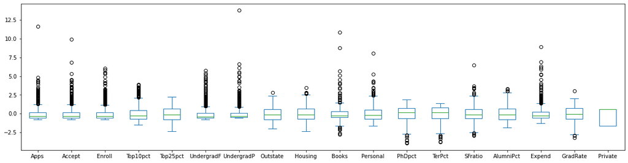

```python
colleges_z = (colleges - colleges.mean())/colleges.std() # convert to z-scores

colleges_z.plot(kind='box', figsize=(20,5))
```

```python
def is_outlier(x):
    Q25, Q75 = x.quantile([.25,.75])
    I = Q75 - Q25
    return (x < Q25 - 1.5*I) |  (x > Q75 + 1.5*I)

outliers = colleges.transform(is_outlier)

colleges_reg = colleges[~outliers] # non-outlier data

colleges_reg.dropna(inplace = True) # outliers flagged with NaN

colleges_reg.head(5)
```

|  | Apps | Accept | Enroll | Top10pct | Top25pct | UndergradF | UndergradP | Outstate | Housing | Books | Personal | PhDpct | TerPct | SFratio | AlumniPct | Expend | GradRate | Private |
| --- | --- | --- | --- | --- | --- | --- | --- | --- | --- | --- | --- | --- | --- | --- | --- | --- | --- | --- |
| Abilene Christian University | 1660.0 | 1232.0 | 721.0 | 23.0 | 52 | 2885.0 | 537.0 | 7440.0 | 3300.0 | 450.0 | 2200.0 | 70.0 | 78.0 | 18.1 | 12.0 | 7041.0 | 60.0 | 1 |
| Adrian College | 1428.0 | 1097.0 | 336.0 | 22.0 | 50 | 1036.0 | 99.0 | 11250.0 | 3750.0 | 400.0 | 1165.0 | 53.0 | 66.0 | 12.9 | 30.0 | 8735.0 | 54.0 | 1 |
| Albertson College | 587.0 | 479.0 | 158.0 | 38.0 | 62 | 678.0 | 41.0 | 13500.0 | 3335.0 | 500.0 | 675.0 | 67.0 | 73.0 | 9.4 | 11.0 | 9727.0 | 55.0 | 1 |
| Albertus Magnus College | 353.0 | 340.0 | 103.0 | 17.0 | 45 | 416.0 | 230.0 | 13290.0 | 5720.0 | 500.0 | 1500.0 | 90.0 | 93.0 | 11.5 | 26.0 | 8861.0 | 63.0 | 1 |
| Albion College | 1899.0 | 1720.0 | 489.0 | 37.0 | 68 | 1594.0 | 32.0 | 13868.0 | 4826.0 | 450.0 | 850.0 | 89.0 | 100.0 | 13.7 | 37.0 | 11487.0 | 73.0 | 1 |

This process removed a significant amount of data from analysis, summarized below.

```python
org_num_colleges = len(colleges['Private'])
reg_num_colleges = len(colleges_reg['Private'])

print('Original number of colleges: ' + str(org_num_colleges) )
print('Number of outlier colleges: ' + str(org_num_colleges - reg_num_colleges) )
print('Number of remaining colleges: ' + str(reg_num_colleges) )
```

```
Original number of colleges: 777
Number of outlier colleges: 238
Number of remaining colleges: 539
```

While the number of dropped rows is significant, there is still an ample amount of colleges for analysis. Therefore, this cleaned data is used.

With the outliers removed from the data, the regression matrices are created. The non-financial related features and financial related features can be seperated into two categories. To begin with, the feature matrix is defined using only financially independent features, but further analysis will involve both. The target matrix is defined as the out-of-state tuition cost in either case.

```python
non_financial = ['Apps', 'Accept', 'Enroll', 'Top10pct', 'Top25pct', 'UndergradF', 'UndergradP', 'PhDpct', 'TerPct', 'SFratio', 'GradRate', 'Private']
financial = ['Housing', 'Books', 'Personal', 'AlumniPct']

X_nf = colleges_reg[non_financial]
X_f = colleges_reg[financial]

X_nf.head(5)
```

|  | Apps | Accept | Enroll | Top10pct | Top25pct | UndergradF | UndergradP | PhDpct | TerPct | SFratio | GradRate | Private |
| --- | --- | --- | --- | --- | --- | --- | --- | --- | --- | --- | --- | --- |
| Abilene Christian University | 1660.0 | 1232.0 | 721.0 | 23.0 | 52 | 2885.0 | 537.0 | 70.0 | 78.0 | 18.1 | 60.0 | 1 |
| Adrian College | 1428.0 | 1097.0 | 336.0 | 22.0 | 50 | 1036.0 | 99.0 | 53.0 | 66.0 | 12.9 | 54.0 | 1 |
| Albertson College | 587.0 | 479.0 | 158.0 | 38.0 | 62 | 678.0 | 41.0 | 67.0 | 73.0 | 9.4 | 55.0 | 1 |
| Albertus Magnus College | 353.0 | 340.0 | 103.0 | 17.0 | 45 | 416.0 | 230.0 | 90.0 | 93.0 | 11.5 | 63.0 | 1 |
| Albion College | 1899.0 | 1720.0 | 489.0 | 37.0 | 68 | 1594.0 | 32.0 | 89.0 | 100.0 | 13.7 | 73.0 | 1 |

```python
y = colleges_reg["Outstate"] # out of state tuition
y.head(5)
```

```
Abilene Christian University     7440.0
Adrian College                  11250.0
Albertson College               13500.0
Albertus Magnus College         13290.0
Albion College                  13868.0
Name: Outstate, dtype: float64
```

Note that the feature matrix shown is the maximum amount of features which can be used for the analysis. Later calculations may reduce this to show only the most relevent features--for example, the number of applications and the number of accepted students can be reduced to an acceptance rate metric. For now, the complete non-financial feature matrix is used with the out-of-state tuition cost as the label matrix.

The data is finally split into a testing and training set in order to test an unlabelled set of data in each regression. A value of 20% is set for the testing size given the relatively smaller number of data entries.

```python
X_train, X_test, y_train, y_test = train_test_split(X_nf, y, test_size=0.2, random_state=2132)
X_train.head(5)
```

|  | Apps | Accept | Enroll | Top10pct | Top25pct | UndergradF | UndergradP | PhDpct | TerPct | SFratio | GradRate | Private |
| --- | --- | --- | --- | --- | --- | --- | --- | --- | --- | --- | --- | --- |
| Northeast Missouri State University | 6040.0 | 4577.0 | 1620.0 | 36.0 | 72 | 5640.0 | 266.0 | 69.0 | 72.0 | 15.7 | 76.0 | 0 |
| Wisconsin Lutheran College | 152.0 | 128.0 | 75.0 | 17.0 | 41 | 282.0 | 22.0 | 48.0 | 48.0 | 8.5 | 50.0 | 1 |
| Connecticut College | 3035.0 | 1546.0 | 438.0 | 42.0 | 93 | 1630.0 | 232.0 | 86.0 | 95.0 | 10.7 | 91.0 | 1 |
| Centenary College | 369.0 | 312.0 | 90.0 | 12.0 | 46 | 396.0 | 526.0 | 41.0 | 85.0 | 9.5 | 24.0 | 1 |
| Trinity University | 2425.0 | 1818.0 | 601.0 | 62.0 | 93 | 2110.0 | 95.0 | 94.0 | 96.0 | 9.6 | 93.0 | 1 |

```python
y_train.head(5)
```

```
Northeast Missouri State University     4856.0
Wisconsin Lutheran College              9100.0
Connecticut College                    18740.0
Centenary College                      11400.0
Trinity University                     12240.0
Name: Outstate, dtype: float64
```

### Feature Correlation

While there are 12 total features used for regression modelling, some of the features may be correlated which can reduce the feature set to analyze. The correlation between features is done by considering which set of features may be correlated and conducting a gridwise plot. The sets to be analyzed are:

- student body size : applications, enrollment, and accepted population sizes
- high school demographics : top 10 and 25 percent enrollment
- small school factor : PhD and terminal degree percentages, student-faculty ratio, and undergraduate population

For each of these sets analyzed, the spearman coefficient is determined between each pairwise plot.

|  | Apps | Accept | Enroll |
| --- | --- | --- | --- |
| Apps | NaN | 0.980951 | 0.888869 |
| Accept | 0.980951 | NaN | 0.911546 |
| Enroll | 0.888869 | 0.911546 | NaN |

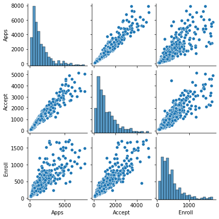

```python
# Student Body Size
cols = ["Apps", "Accept", "Enroll"]
sns.pairplot(data=X_nf[cols], height=2);

pw_spearman = X_nf[cols].corr(method = 'spearman') # compute pairwise spearman correlation
# Remove diagonals
for i in range(len(cols)):
    for j in range(len(cols)):
        if i==j:
            pw_spearman.iloc[i,j] = None # remove value

pw_spearman
```

There is a very strong correlation between the number of applications and the number of accepted students, so we convert these features into a single feature called the acceptance rate, which is the ratio of the accepted students to the applications. Note that in doing so we lose the respective magnitude of the number of applications, but there is still a decent correlation between the student enrollment and the number of accepted students, so this information is not lost. In other words, both the incoming student body size and the information about the application to acceptance ratio are preserved.

```python
colleges_reg['AccRate'] = 100* colleges_reg['Accept'] / colleges_reg['Apps'] # acceptance rate as percentage
```

Next, the correlation between the high school achievement is plotted.

```
Spearman correlation: 0.9024959609998393
```

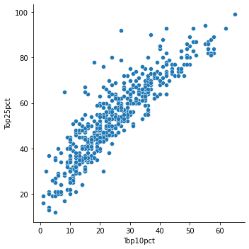

```python
# High School Demographics
sns.relplot(data=colleges_reg,
    x="Top10pct", y="Top25pct"
    );
print("Spearman correlation: " + str(X_nf["Top10pct"].corr(X_nf["Top25pct"],"spearman")) )
```

The above correlation is above 0.9 so we consider this strongly correlated and thus can remove one of the features from the analysis. For this, the top 25 percent data is omitted as it is suspected that the top 10 percent might have a better ability to predict tuition rate.

Lastly, the "small school factor" is assessed for correlation. For this we also compute the relationship between the undergraduate student population and see if the distribution of full and part time students is a constant ratio.

```
Undergraduate distribution spearman correlation: 0.4018358685729641
```

|  | Undergrads | PhDpct | TerPct | SFratio |
| --- | --- | --- | --- | --- |
| Undergrads | NaN | 0.215165 | 0.182446 | 0.462291 |
| PhDpct | 0.215165 | NaN | 0.848562 | -0.070788 |
| TerPct | 0.182446 | 0.848562 | NaN | -0.133848 |
| SFratio | 0.462291 | -0.070788 | -0.133848 | NaN |

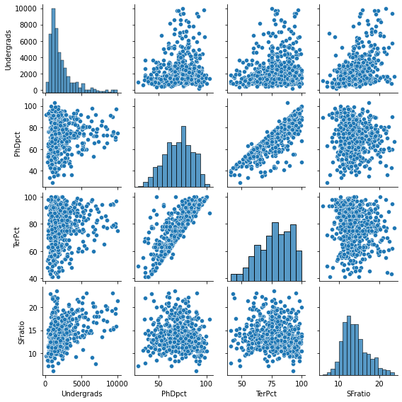

```python
# Small School Factor

undergrad_spr = X_nf["UndergradP"].corr(X_nf["UndergradF"], "spearman")
print("Undergraduate distribution spearman correlation: " + str(undergrad_spr))

# compute undergrad population
X_nf_temp = X_nf # copy data
undergrads = X_nf_temp["UndergradP"] + X_nf_temp["UndergradF"]
X_nf_temp["Undergrads"] = pd.Series(undergrads)

cols = ["Undergrads","PhDpct", "TerPct", "SFratio"]

sns.pairplot(data=X_nf_temp[cols], height=2);

pw_spearman = X_nf_temp[cols].corr(method = 'spearman') # compute pairwise spearman correlation
# Remove diagonals
for i in range(len(cols)):
    for j in range(len(cols)):
        if i==j:
            pw_spearman.iloc[i,j] = None # remove value

X_nf = X_nf.drop(columns = ["Undergrads"]) # remove temporary column

pw_spearman
```

From the above results, it is concluded that the accepted students, applications, and top 25 percentage data can be omitted from the analysis and be replaced only using an acceptance rate metric.

Let "X_nf" denote the features containing all non-financial features, "X_uc" denoting those features which are uncorrelated as discussed in this section, and "X" to be the most reduced set of features which is discussed in later sections. Financial features, and features previously thought to be correlated may be used in later analysis. The testing and training data sets are redefined using the above analysis.

```python
X = colleges_reg[['AccRate', 'Enroll', 'Top10pct', 'UndergradF', 'UndergradP', 'PhDpct', 'TerPct', 'SFratio', 'GradRate', 'Private']]

X_uc_train, X_uc_test, y_train, y_test = train_test_split(X, y, test_size=0.2, random_state=2132) # simplified data
X_nf_train, X_nf_test, y_train, y_test = train_test_split(X_nf, y, test_size=0.2, random_state=2132) # full data

X_uc_train.head(5)
```

|  | AccRate | Enroll | Top10pct | UndergradF | UndergradP | PhDpct | TerPct | SFratio | GradRate | Private |
| --- | --- | --- | --- | --- | --- | --- | --- | --- | --- | --- |
| Northeast Missouri State University | 75.778146 | 1620.0 | 36.0 | 5640.0 | 266.0 | 69.0 | 72.0 | 15.7 | 76.0 | 0 |
| Wisconsin Lutheran College | 84.210526 | 75.0 | 17.0 | 282.0 | 22.0 | 48.0 | 48.0 | 8.5 | 50.0 | 1 |
| Connecticut College | 50.939044 | 438.0 | 42.0 | 1630.0 | 232.0 | 86.0 | 95.0 | 10.7 | 91.0 | 1 |
| Centenary College | 84.552846 | 90.0 | 12.0 | 396.0 | 526.0 | 41.0 | 85.0 | 9.5 | 24.0 | 1 |
| Trinity University | 74.969072 | 601.0 | 62.0 | 2110.0 | 95.0 | 94.0 | 96.0 | 9.6 | 93.0 | 1 |

# Results

The following regressions are performed on the dataset: (1) LASSO, (2) Ridge, and (3) non-linear. The first two regularize the least squares model for a weight sharing (Ridge) or sparcity inducing (LASSO) result which favor simplified regression models.

### Linear Regression

The regular linear model is first computed to find a reference coefficient of determination ($R^2$) value which the other regression models can be compared to. For this, a pipeline is fit to give each column an equal range of values to determine the overall tuition cost; in the current data the student population can be in the thousands while the "private" column is at most 1 so standardization is needed.

The regression score is computed for the simplified data set, those with correlated features removed, and for the full data set, taken to be the complete non-financial set of features. This evaluates whether the above analysis is valid in that removing these correlated features can achieve similar results with much less data.

```python
# Linear Model
lm_nf = LinearRegression()
lm_red = LinearRegression()
pipe_nf = make_pipeline(StandardScaler(), lm_nf) # make a pipeline to standardize columns
pipe_red = make_pipeline(StandardScaler(), lm_red)

# Full data set
pipe_nf.fit(X_nf_train, y_train) # fit to training data
lin_score_nf = pipe_nf.score(X_nf_test, y_test) # score on testing data
print("Linear R^2 score, full feature set:", f"{lin_score_nf:.5f}")

# Uncorrelated data set
pipe_red.fit(X_uc_train, y_train) # fit to training data
lin_score_unc = pipe_red.score(X_uc_test, y_test) # score on testing data
print("Linear R^2 score, uncorrelated feature set:", f"{lin_score_unc:.5f}")

pct_red = (lin_score_nf - lin_score_unc) / lin_score_nf
print("Score reduction: " + f"{(pct_red*100):0.3f}" + "%")
```

```
Linear R^2 score, full feature set: 0.68001
Linear R^2 score, uncorrelated feature set: 0.63242
Score reduction: 6.998%
```

The weight coefficient for each feature in this regression can be determined to quantify how significant each feature is to the overall predicted tuition value. These weights can be standardized themselves to provide a way to compare the values relative to the group. To do this, the z-score is computed for the weight vector.

```python
data_lin = pd.DataFrame( {
    "feature": X_nf.columns,
    "Linear": pipe_nf[1].coef_
    } ) # weight vector

data_lin_sorted = data_lin.sort_values(by="Linear") #sort data by weight score
# compute z-scores
data_lin_sorted["Linear_z"] = (data_lin_sorted["Linear"] - data_lin_sorted["Linear"].mean())/data_lin_sorted["Linear"].std()

data_lin_sorted.reset_index(drop=True, inplace = True) # reset numerical indices

data_lin_sorted
```

|  | feature | Linear | Linear_z |
| --- | --- | --- | --- |
| 0 | Enroll | -1506.717952 | -1.579336 |
| 1 | Apps | -786.863348 | -0.923764 |
| 2 | SFratio | -719.506269 | -0.862422 |
| 3 | UndergradF | -292.914322 | -0.473924 |
| 4 | Top25pct | -34.051891 | -0.238178 |
| 5 | UndergradP | 62.373969 | -0.150363 |
| 6 | PhDpct | 211.419077 | -0.014627 |
| 7 | Top10pct | 613.126309 | 0.351208 |
| 8 | GradRate | 619.775148 | 0.357263 |
| 9 | TerPct | 732.828823 | 0.460221 |
| 10 | Private | 990.837763 | 0.695190 |
| 11 | Accept | 2839.456200 | 2.378729 |

```python
print('Highest pos correlated: ' + str( data_lin_sorted['feature'][11] ) )
print('Highest neg correlated: ' + str( data_lin_sorted['feature'][0] ) )
```

```
Highest pos correlated: Accept
Highest neg correlated: Enroll
```

With the linear regression, a decent correlation is found as the baseline which allows the regularization and other non-linear regressions to match or improve these results.

### LASSO Regression

For the LASSO regression, a range of $\alpha$ values are tested for the best coefficient of determination score.

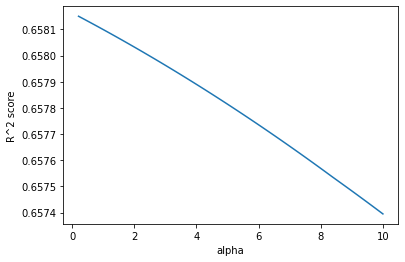

```python
kf = KFold(n_splits=4, shuffle=True, random_state=302)
alpha = np.linspace(0, 10, 50)[1:]  # exclude alpha=0

_,scores = validation_curve(
    Lasso(),
    X_nf_train, y_train,
    cv=kf,
    n_jobs=-1,
    param_name="alpha", param_range=alpha
    )

fig = sns.lineplot(x=alpha, y=np.mean(scores, axis=1) );
fig.set(xlabel="alpha", ylabel="R^2 score");
```

As observed in the validation curve above, increasing the $\alpha$ parameter only decreases the $R^2$ score suggesting that an $\alpha=0$, equal to a linear regression, is best. The weight of each feature using the best $\alpha$ can be found in order to determine which features can be omitted from analysis. Note that the minimum non-zero value of $\alpha$ is used to avoid reproducing the same results as the linear regression.

```python
best_alp = alpha[np.mean(scores,axis=1).argmax()] # get best alpha value from plot before

lass = Lasso(alpha=best_alp)
pipe_lass = make_pipeline(StandardScaler(), lass) # make pipeline
pipe_lass.fit(X_nf_train, y_train) # fit best lasso curve

data_las = pd.DataFrame( {
    "feature": X_nf.columns,
    "LASSO": pipe_lass[1].coef_
    } )

lass_score_1 = pipe_lass.score(X_nf_test, y_test)
print(f"Best coefficient of determination: ", f"{lass_score_1 :.5f}")

data_las = data_las.sort_values(by="LASSO") # sort values
data_las.reset_index(drop=True, inplace = True) # reset numerical indices

data_las
```

```
Best coefficient of determination:  0.67999
```

|  | feature | LASSO |
| --- | --- | --- |
| 0 | Enroll | -1503.929429 |
| 1 | Apps | -781.725753 |
| 2 | SFratio | -719.425070 |
| 3 | UndergradF | -293.279955 |
| 4 | Top25pct | -32.550627 |
| 5 | UndergradP | 61.888626 |
| 6 | PhDpct | 211.405658 |
| 7 | Top10pct | 611.267706 |
| 8 | GradRate | 619.595481 |
| 9 | TerPct | 732.874996 |
| 10 | Private | 991.518574 |
| 11 | Accept | 2832.596764 |

```python
print('Highest correlated: ' + str( data_las["feature"][11] ) )
print('Lowest correlated: ' + str( data_las["feature"][0] ) )
```

```
Highest correlated: Accept
Lowest correlated: Enroll
```

As expected, the results are almost identical to the linear regression only with a slightly worse coefficient of determination score.

With these LASSO weights, the best and worst features for regression can be analyzed. For each weight described by the LASSO regression, the absolute value is found to compare which features are the strongest, regardless of positive or negative correlation. The weight values are then standardized such that a new value, called the $L_z$ score, denotes the percentage of the weight to the total weight sum. That is, $\Sigma L_z$ = 100% across each of the features.

```python
wt_sum = sum(abs(data_las["LASSO"])) # sum of all weights

data_las["Lz%"] = 100* abs(data_las["LASSO"]) / wt_sum # create Lz score

data_las.sort_values(by="Lz%", inplace = True) # sort by Lz score
data_las.reset_index(drop=True, inplace = True) # reset numerical indices

data_las
```

|  | feature | LASSO | Lz% |
| --- | --- | --- | --- |
| 0 | Top25pct | -32.550627 | 0.346576 |
| 1 | UndergradP | 61.888626 | 0.658946 |
| 2 | PhDpct | 211.405658 | 2.250898 |
| 3 | UndergradF | -293.279955 | 3.122638 |
| 4 | Top10pct | 611.267706 | 6.508346 |
| 5 | GradRate | 619.595481 | 6.597015 |
| 6 | SFratio | -719.425070 | 7.659929 |
| 7 | TerPct | 732.874996 | 7.803135 |
| 8 | Apps | -781.725753 | 8.323263 |
| 9 | Private | 991.518574 | 10.556989 |
| 10 | Enroll | -1503.929429 | 16.012777 |
| 11 | Accept | 2832.596764 | 30.159488 |

This analysis suggests that the top 25 percent of high school students as well as the part-time undergraduate student population features contribute less than 1% to the final prediction in either a positive or negative sense. Therefore, these features can be omitted from the analysis as they have negligible contributions to the regression.

This can be validated by performing the linear and LASSO regressions again with this reduced set of features shown below.

```python
non_financial_2 = list(data_las["feature"][2:]) # reduced set of features
print("Features used in analysis: ")
print(non_financial_2)
```

```
Features used in analysis:
['PhDpct', 'UndergradF', 'Top10pct', 'GradRate', 'SFratio', 'TerPct', 'Apps', 'Private', 'Enroll', 'Accept']
```

```python
X_nf_2 = colleges_reg[non_financial_2] # redefine feature matrix
X_train, X_test, y_train, y_test = train_test_split(X_nf_2, y, test_size=0.2, random_state=2132) # X denotes reduced set

# Linear Model
lm_red_2 = LinearRegression()
pipe_lin_red = make_pipeline(StandardScaler(), lm_red_2)
pipe_lin_red.fit(X_train, y_train) # fit to training data
lin_score_red = pipe_lin_red.score(X_test, y_test) # score on testing data
print("Linear R^2 score:", f"{lin_score_red:.5f}")
```

```
Linear R^2 score: 0.68104
```

The linear regression sees a small increase in the coefficient in determination when using this reduced list of features which not only validates the assumption that the features omitted were in fact negligable, but also shows the reducing said features can improve the regression's ability to predict the correct tuition value.

The LASSO regression is performed again with this reduced set of features.

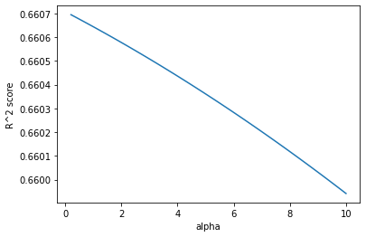

```python
kf = KFold(n_splits=4, shuffle=True, random_state=302)
alpha = np.linspace(0, 10, 50)[1:]  # exclude alpha=0

_,scores = validation_curve(
    Lasso(),
    X_train, y_train,
    cv=kf,
    n_jobs=-1,
    param_name="alpha", param_range=alpha
    )

fig = sns.lineplot(x=alpha, y=np.mean(scores, axis=1) );
fig.set(xlabel="alpha", ylabel="R^2 score");
```

```python
best_alp = alpha[np.mean(scores,axis=1).argmax()] # get best alpha value from plot before

lass_2 = Lasso(alpha=best_alp)
pipe_lass_2 = make_pipeline(StandardScaler(), lass_2)
pipe_lass_2.fit(X_train, y_train) # fit best lasso curve

lass_score_red = pipe_lass_2.score(X_test, y_test)
print(f"Best coefficient of determination: ", f"{lass_score_red:.5f}")
```

```
Best coefficient of determination:  0.68105
```

As observed, the LASSO regression score also experiences a slight increase which validates these results. The set of features used in the analysis is then shown below, listed from least (left) to most (right) significant.

```python
X_train.head(5)
```

|  | PhDpct | UndergradF | Top10pct | GradRate | SFratio | TerPct | Apps | Private | Enroll | Accept |
| --- | --- | --- | --- | --- | --- | --- | --- | --- | --- | --- |
| Northeast Missouri State University | 69.0 | 5640.0 | 36.0 | 76.0 | 15.7 | 72.0 | 6040.0 | 0 | 1620.0 | 4577.0 |
| Wisconsin Lutheran College | 48.0 | 282.0 | 17.0 | 50.0 | 8.5 | 48.0 | 152.0 | 1 | 75.0 | 128.0 |
| Connecticut College | 86.0 | 1630.0 | 42.0 | 91.0 | 10.7 | 95.0 | 3035.0 | 1 | 438.0 | 1546.0 |
| Centenary College | 41.0 | 396.0 | 12.0 | 24.0 | 9.5 | 85.0 | 369.0 | 1 | 90.0 | 312.0 |
| Trinity University | 94.0 | 2110.0 | 62.0 | 93.0 | 9.6 | 96.0 | 2425.0 | 1 | 601.0 | 1818.0 |

### Ridge Regression

For the Ridge regression, the $\alpha$ value is determined by testing a range of values and determining the value with the best coefficient of determination score. As $\alpha$ increases, the Euclidean norm of the coefficient vector becomes smaller to create a "simpler" model, but comes at the penalty of a lower coefficient. The optimal value is therefore determined by plotting each coefficient of determination per $\alpha$ value.

```
Reduced Ridge R^2 score: 0.68157
Best alpha value:  3.075
```

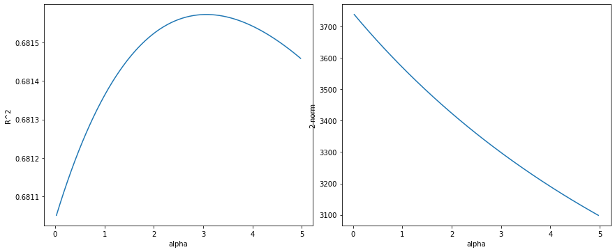

```python
# Ridge Regression
alphas = [] # alpha values measured
r2_scores = [] # associated scores
wt_norms = [] # euclidean norm of feature weights

for a in range(1, 200, 1): # test 300 values, skip alpha=0
    alp = a * (5/200) # alpha ranges from 0 to 5
    rr_1 = Ridge(alpha=alp)    # more regularization
    pipe_rr_1 = make_pipeline(StandardScaler(), rr_1)
    pipe_rr_1.fit(X_train, y_train)
    alphas.append(alp) # add to alpha list
    r2_scores.append(pipe_rr_1.score(X_test, y_test)) # add score
    wt_norms.append(norm(pipe_rr_1[1].coef_)) # add norm

ridge_r2_1 = max(r2_scores[1:])
print("Reduced Ridge R^2 score:" , f"{ridge_r2_1:.5f}") # exclude first value (alpha=0)
print("Best alpha value: ", f"{alphas[r2_scores.index(ridge_r2_1)]:0.3f}")

fig, axes = plt.subplots(nrows=1, ncols=2, figsize=(12, 5))
fig.tight_layout()

# R^2 plot
plt.subplot(1,2,1)
plt.plot(alphas, r2_scores)
plt.xlabel('alpha')
plt.ylabel('R^2')

# 2-norm plot
plt.subplot(1,2,2)
plt.plot(alphas, wt_norms)
plt.xlabel('alpha')
plt.ylabel('2-norm')

plt.show()
```

As observed, increasing the $\alpha$ causes the ridge regularization to produce a score exceeding the previous regression values. The strength of this effect is compared to the original complete set of features to see if using the non-reduced set causes a significantly larger regression score increase.

```python
# Ridge Regression
alphas = [] # alpha values measured
r2_scores = [] # associated scores
wt_norms = [] # euclidean norm of feature weights

for a in range(1, 200, 1): # test 100 values
    alp = a * (5/200) # alpha ranges from 0 to 5
    rr_2 = Ridge(alpha=alp)    # more regularization
    pipe_rr_2 = make_pipeline(StandardScaler(), rr_2) # use pipeline
    pipe_rr_2.fit(X_nf_train, y_train)
    alphas.append(alp) # add to alpha list
    r2_scores.append(pipe_rr_2.score(X_nf_test, y_test)) # add score
    wt_norms.append(norm(pipe_rr_2[1].coef_)) # add norm

ridge_r2_2 = max(r2_scores[1:])
print("Non-Reduced Ridge R^2 score:" , f"{ridge_r2_2:.5f}") # exclude first value (alpha=0)
print("Best alpha value: ", f"{alphas[r2_scores.index(ridge_r2_2)]:0.3f}")
```

```
Non-Reduced Ridge R^2 score: 0.68055
Best alpha value:  2.950
```

The percent increase of the $R^2$ value using the Ridge regression with the full non-financial feature set as compared to the reduced feature set is calculated below.

```python
print("Percent increase of Ridge R^2: ", f"{100*(ridge_r2_2-ridge_r2_1)/ridge_r2_1:0.5f}")
```

```
Percent increase of Ridge R^2:  -0.15061
```

As observed, the ridge regression performs worse with the original, non-financial set of features as compared to the set of non-financial features which were determined to be signifcant to the analysis using the LASSO regularization. The reduced set of features are again validated as the only significant set of features to use.

The corresponding weights gathered using this reduced set of features for the ridge regression can be found and compared to the other linear regression weights. For each previous regression type (the plain linear and the LASSO regularized regression), the feature weights corresponding to the best regression score are displayed, indexed by feature.

```python
# Linear
lin_wts = pd.DataFrame( {
    "feature": X_train.columns,
    "Linear": pipe_lin_red[1].coef_
    } ) # linear weights, reduced feature set
lin_wts.set_index('feature', inplace=True) # index by feature

# LASSO
lass_wts = pd.DataFrame( {
    "feature": X_train.columns,
    "LASSO": pipe_lass_2[1].coef_
    } ) # lasso weights, reduced feature set
lass_wts.set_index('feature', inplace=True) # index by feature

# Ridge
rr_wts = pd.DataFrame( {
    "feature": X_train.columns,
    "Ridge": pipe_rr_1[1].coef_
    } ) # ridge weights, reduced feature set
rr_wts.set_index('feature', inplace=True) # index by feature

# Merge weight values, all indices are in same order by default
frame = {"Linear" : lin_wts["Linear"], "LASSO" : lass_wts["LASSO"], "Ridge" : rr_wts["Ridge"]}
all_wts = pd.DataFrame(frame)
all_wts.sort_values(by="Ridge", ascending=False, inplace=True) # sort by ridge score

# Gather scores, append to dataframe
all_scores = {"Linear" : [lin_score_red], "LASSO" : [lass_score_red], "Ridge" : [ridge_r2_1]}
scores = pd.DataFrame(data=all_scores, index=["R^2"])

# add empty row of data
all_wts = pd.concat([all_wts, pd.DataFrame(data={"Linear" : [' '], "LASSO" : [' '], "Ridge" : [' ']},index=[' '])], ignore_index = False)
# add R^2 scores
all_wts = pd.concat([all_wts, scores], ignore_index = False)
all_wts
```

|  | Linear | LASSO | Ridge |
| --- | --- | --- | --- |
| Accept | 2859.101456 | 2851.748094 | 2248.940443 |
| Private | 991.525513 | 992.21873 | 1032.91443 |
| TerPct | 732.412857 | 732.563779 | 735.306665 |
| GradRate | 616.950962 | 616.856767 | 619.146294 |
| Top10pct | 573.273606 | 572.780274 | 531.294577 |
| PhDpct | 202.599214 | 202.63151 | 231.717265 |
| UndergradF | -242.083707 | -242.688536 | -377.021603 |
| Apps | -795.436993 | -790.005652 | -377.653957 |
| SFratio | -716.367382 | -716.320984 | -716.131031 |
| Enroll | -1537.566033 | -1534.489051 | -1190.533883 |
| R^2 | 0.681041 | 0.681053 | 0.681572 |

As observed, the ranking of the linear regression weights are generally consistent with the number of accepted students, the private status, and the percentage of terminary degree pocessing faculty being the strongest weighted features. Adding regularization to the linear regression improves the coefficient of determination score slightly in both the cases of a LASSO and Ridge regularization method.

### Non-Linear Regression

A k-nearest neighbors (kNN) algorithm can be computed for this dataset to observe the degree to which the tuition is better predicted using a non-linear algorithm compared to the linear regressions before. For this, a grid search is used over the number of neighbors as well as the distance weighting metric and associated norm to determine the ideal hyperparameters to use for the analysis.

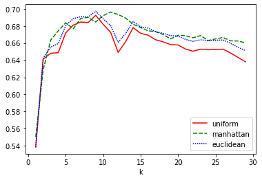

```python
# Uniform metric scores
scores_u = []
# Distance metric scores
scores_d1 = [] # manhatten distance
scores_d2 = [] # euclidean distance

k_vals = [] # values of k to search through
k_max = 30 # maximum k value to search for

kf = KFold(n_splits=6, shuffle=True, random_state=1995) # use 6 folds

# Uniform
for k in range(1,k_max,1): # range from k=1 to k=20
    k_vals.append(k) # add k to measurement data
    kNN = KNeighborsRegressor(n_neighbors=k, weights='uniform')
    kNN_pipe = make_pipeline(StandardScaler(), kNN)
    kNN_pipe.fit(X_train, y_train)
    scores_u.append(kNN_pipe.score(X_test, y_test))

# Distance: Manhattan
for k in range(1,k_max,1): # range from k=1 to k=20
    kNN = KNeighborsRegressor(n_neighbors=k, weights='distance', metric='manhattan')
    kNN_pipe = make_pipeline(StandardScaler(), kNN)
    kNN_pipe.fit(X_train, y_train)
    scores_d1.append(kNN_pipe.score(X_test, y_test))

# Distance: Manhattan
for k in range(1,k_max,1): # range from k=1 to k=20
    kNN = KNeighborsRegressor(n_neighbors=k, weights='distance', metric='euclidean')
    kNN_pipe = make_pipeline(StandardScaler(), kNN)
    kNN_pipe.fit(X_train, y_train)
    scores_d2.append(kNN_pipe.score(X_test, y_test))

data = {"k" : k_vals, "uniform" : scores_u, "manhattan" : scores_d1, "euclidean" : scores_d2}
r2_scores = pd.DataFrame(data=data, index=k_vals)
r2_scores.set_index("k", inplace=True) # index by k

sns.lineplot(data=r2_scores[['uniform', 'manhattan', 'euclidean']],
             palette = ['red', 'green', 'blue'],
             linestyle = 'solid')
```

As observed, there is an optimal number of neighbors $k$ in each of the algorithms computed. This gives a maximum coefficient of determination score for this non-linear regression by finding the maximum value of $R^2$ amongst the entire search space.

```python
# Uniform
best_u_r2 = r2_scores['uniform'].max()
best_u_k = k_vals[r2_scores['uniform'].argmax()]

# Manhattan
best_d1_r2 = r2_scores['manhattan'].max()
best_d1_k = k_vals[r2_scores['manhattan'].argmax()]

# Euclidean
best_d2_r2 = r2_scores['euclidean'].max()
best_d2_k = k_vals[r2_scores['euclidean'].argmax()]

mets = ['uniform', 'manhattan', 'euclidean'] # metrics used
vals = [best_u_r2, best_d1_r2, best_d2_r2] # list of best scores
ks = [best_u_k, best_d1_k, best_d2_k] # list of best associated k values

best_r2_val = max(vals)
best_r2_m = mets[np.argmax(vals)]
best_r2_k = ks[np.argmax(vals)]

print("Best kNN computed using " + str(best_r2_m) + " metric with k=" + str(best_r2_k) )
print("kNN R^2 score = " + str(best_r2_val))
```

```
Best kNN computed using euclidean metric with k=9
kNN R^2 score = 0.6972190555157138
```

The non-linear regression performs better than the linear regressions as expected. While the performance is only slightly better, it still proves the capabilities of such an algorithm and provides promising results for the predicter's abilities.

# Discussion

### Regression Summary

The coefficient of determination for each regression method performed is listed in the table below. The column headers are defined as:

- model : type of regression model used (e.g., linear, linear with LASSO regularization, non-linear, etc.)
- set : features used in the analysis, either non-financial features or financial features
- features : all available features (full), features not omitted in the analysis from the LASSO regression results (reduced), or features found to not be correlated from the pre-processing results (uncorrelated)
- R^2 : the best performing coefficient of determination score, if multiple were found

```python
data = {"model" : ["Linear", "Linear", "LASSO", "Linear", "LASSO", "Ridge", "Ridge", "kNN"],
        "set" : ["Non-financial", "Non-financial", "Non-financial", "Non-financial", "Non-financial", "Non-financial", "Non-financial", "Non-financial"],
        "features" : ["Full", "Uncorrelated", "Full", "Reduced", "Reduced", "Reduced", "Full", "Reduced"],
        "R^2": [lin_score_nf, lin_score_unc, lass_score_1, lin_score_red, lass_score_red, ridge_r2_1, ridge_r2_2, best_r2_val]}

r2_scores = pd.DataFrame(data=data) # make dataframe
r2_scores.sort_values(by="R^2", ascending=False, inplace=True) # sort by score
r2_scores.reset_index(drop=True, inplace = True) # reset numerical indices

r2_scores # display data
```

|  | model | set | features | R^2 |
| --- | --- | --- | --- | --- |
| 0 | kNN | Non-financial | Reduced | 0.697219 |
| 1 | Ridge | Non-financial | Reduced | 0.681572 |
| 2 | LASSO | Non-financial | Reduced | 0.681053 |
| 3 | Linear | Non-financial | Reduced | 0.681041 |
| 4 | Ridge | Non-financial | Full | 0.680546 |
| 5 | Linear | Non-financial | Full | 0.680006 |
| 6 | LASSO | Non-financial | Full | 0.679995 |
| 7 | Linear | Non-financial | Uncorrelated | 0.632418 |

Of all the regression models tested, the non-linear, k-nearest neighbors performed the best. This method allows for more complexities in the features as instead of trying to fit the data to a simplified linear equation, the regression simply averages the score of the nearby data points and thus with increasing population sizes, the large gaps in data, non-uniform distribution of values, etc. will have no effect on the regression. Such is observed with this set of data with features having a wide range of values and different distributions, as shown from the z-scores in the pre-processing section of the report.

A LASSO regularization was performed which suggested that the features relating to the top 25% of high school graduates in the student body and the part-time undergraduate student population had negligible effects on the regression performance and could be omitted. This actually caused an increase in regression performance, likely as reducing the feature set simplified the model and prevented overfitting the data to the training set. With both the Ridge and LASSO regularization methods, this reduced set of features proved to have a higher performance.

The Ridge regression had a higher overall coefficient of determination score compared to the LASSO regression, both optimized with their respective hyperparameters. This is likley explained by the LASSO regression creating a sparce set of features and tries to simplify the model as best as possible in terms of limited features which casuses a drop in perfomance as the value $\alpha$ increases. For the Ridge regression, however, the weights of the features attempt to be distributed more evenly and thus a maximum is created between using the original linear regression ($\alpha=0$) and using an equal distributed set of weights with the details lost ($\alpha>10$).

The most important features for each linear regression can be identified by measuring the absolute value of that regressions weight and comparing it to the total sum of feature weights. This uses the $L_z$ score as discussed before.

```python
feature_weights = all_wts.iloc[:10] # remove R^2 scores
feature_weights = feature_weights.apply(lambda x: 100*abs(x)/abs(x).sum()) # compute Lz score
feature_weights.sort_values(by="Ridge", ascending=False, inplace=True) # sort by ridge features

print("Feature weight distribution by percentage to overall weight magnitude (Lz value): ")

feature_weights
```

```
Feature weight distribution by percentage to overall weight magnitude (Lz value):
```

|  | Linear | LASSO | Ridge |
| --- | --- | --- | --- |
| Accept | 30.851445 | 30.822034 | 27.900202 |
| Enroll | 16.591274 | 16.584941 | 14.769682 |
| Private | 10.699164 | 10.724019 | 12.814266 |
| TerPct | 7.903181 | 7.917637 | 9.122164 |
| SFratio | 7.73004 | 7.742083 | 8.884273 |
| GradRate | 6.657276 | 6.667062 | 7.681087 |
| Top10pct | 6.185971 | 6.190678 | 6.591204 |
| Apps | 8.583249 | 8.538475 | 4.685149 |
| UndergradF | 2.612231 | 2.623007 | 4.677304 |
| PhDpct | 2.186169 | 2.190066 | 2.874669 |

In all three linear regressions computed, the number of accepted students, the number of enrolled students, and the private school status were the highest weighted features compared to the relative magnitudes of all other features. Across the three regressions, these three features alone accounted for 55-58% of the total feature weight magnitudes and thus were the most significant to each regression. On the opposite end, the percentage of faculty with PhD's, the fulltime undergraduate student population, and the number of applications had little impact on the regression performance. Combined, these features accounted for only 12-13% of the total feature weight magnitudes.

Using the kNN regression with the euclidean metric and k=9, the tuition cost for the University of Delaware can be predicted.

```python
# Actual Value
print("University of Delaware")
k_act = colleges_raw["Outstate"]["University of Delaware"]
print("Actual tuition cost: $", f"{k_act:0.2f}" )

# Preducted Value
# train kNN using best model
kNN = KNeighborsRegressor(n_neighbors=9, weights='distance', metric='euclidean')
kNN_pipe = make_pipeline(StandardScaler(), kNN)
kNN_pipe.fit(X_train, y_train)

# get query data
features = X_train.columns
udel = colleges.loc[["University of Delaware"]] # get row of data
X_query = udel[features]

khat = kNN_pipe.predict(X_query)
print("Predicted tuition cost: $", f"{khat[0]:0.2f}" )
err = 100*(khat[0] - k_act) / k_act
print("Percent error:", f"{err:0.2f}", "%" )
```

```
University of Delaware
Actual tuition cost: $ 10220.00
Predicted tuition cost: $ 9727.27
Percent error: -4.82 %
```

While the regressor is not perfect, it is able to predict the tuition cost of a univeristy using only a set of features completely unrelated to any financial information of the school with a coefficient of determination of $R^2=0.697$.

### Financial Features

The previous analysis focused entirely on predicting the tuition rate using features with no inherent financial information. However, with access to financial data, the regression should be much better in predicting the tuition. The following set of features are used.

```python
X_train, X_test, y_train, y_test = train_test_split(X_f, y, test_size=0.2, random_state=2132) #financial set of features
X_train.head(5)
```

|  | Housing | Books | Personal | AlumniPct |
| --- | --- | --- | --- | --- |
| Northeast Missouri State University | 3416.0 | 400.0 | 1100.0 | 13.0 |
| Wisconsin Lutheran College | 3700.0 | 500.0 | 1400.0 | 26.0 |
| Connecticut College | 6300.0 | 600.0 | 500.0 | 40.0 |
| Centenary College | 5400.0 | 500.0 | 760.0 | 20.0 |
| Trinity University | 5150.0 | 500.0 | 490.0 | 20.0 |

This is a much more limited feature set, but has features which are much closer connected to the tuition costs. The analysis used for the kNN algorithm is performed again, except now with this set of features.

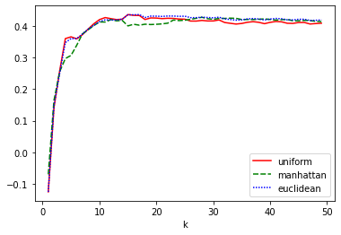

```python
# Uniform metric scores
scores_u = []
# Distance metric scores
scores_d1 = [] # manhatten distance
scores_d2 = [] # euclidean distance

k_vals = [] # values of k to search through
k_max = 50 # maximum k value to search for

kf = KFold(n_splits=6, shuffle=True, random_state=1995) # use 6 folds

# Uniform
for k in range(1,k_max,1): # range from k=1 to k_max
    k_vals.append(k) # add k to measurement data
    kNN = KNeighborsRegressor(n_neighbors=k, weights='uniform')
    kNN_pipe = make_pipeline(StandardScaler(), kNN)
    kNN_pipe.fit(X_train, y_train)
    scores_u.append(kNN_pipe.score(X_test, y_test))

# Distance: Manhattan
for k in range(1,k_max,1): # range from k=1 to k_max
    kNN = KNeighborsRegressor(n_neighbors=k, weights='distance', metric='manhattan')
    kNN_pipe = make_pipeline(StandardScaler(), kNN)
    kNN_pipe.fit(X_train, y_train)
    scores_d1.append(kNN_pipe.score(X_test, y_test))

# Distance: Manhattan
for k in range(1,k_max,1): # range from k=1 to k_max
    kNN = KNeighborsRegressor(n_neighbors=k, weights='distance', metric='euclidean')
    kNN_pipe = make_pipeline(StandardScaler(), kNN)
    kNN_pipe.fit(X_train, y_train)
    scores_d2.append(kNN_pipe.score(X_test, y_test))

data = {"k" : k_vals, "uniform" : scores_u, "manhattan" : scores_d1, "euclidean" : scores_d2}
r2_scores = pd.DataFrame(data=data, index=k_vals)
r2_scores.set_index("k", inplace=True) # index by k

sns.lineplot(data=r2_scores[['uniform', 'manhattan', 'euclidean']],
             palette = ['red', 'green', 'blue'],
             linestyle = 'solid')
```

This regression is observed to perform much worse than before, likely due to the very small feature set used for analysis. The best coefficient of determination score and associated model are found below.

```python
# Uniform
best_u_r2 = r2_scores['uniform'].max()
best_u_k = k_vals[r2_scores['uniform'].argmax()]

# Manhattan
best_d1_r2 = r2_scores['manhattan'].max()
best_d1_k = k_vals[r2_scores['manhattan'].argmax()]

# Euclidean
best_d2_r2 = r2_scores['euclidean'].max()
best_d2_k = k_vals[r2_scores['euclidean'].argmax()]

mets = ['uniform', 'manhattan', 'euclidean'] # metrics used
vals = [best_u_r2, best_d1_r2, best_d2_r2] # list of best scores
ks = [best_u_k, best_d1_k, best_d2_k] # list of best associated k values

best_r2_val_f = max(vals)
best_r2_m = mets[np.argmax(vals)]
best_r2_k = ks[np.argmax(vals)]

print("Best kNN computed using " + str(best_r2_m) + " metric with k=" + str(best_r2_k) )
print("kNN R^2 score = " + str(best_r2_val_f))
```

```
Best kNN computed using uniform metric with k=15
kNN R^2 score = 0.43693840390467686
```

We can retrain the kNN algorithm by using the entire feature set, including both financial and non-financial set of features.

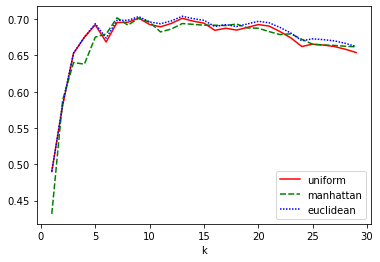

```python
# Redefine datasets
X = colleges_reg[financial + non_financial]
X_train, X_test, y_train, y_test = train_test_split(X, y, test_size=0.2, random_state=2132) #financial set of features

# Uniform metric scores
scores_u = []
# Distance metric scores
scores_d1 = [] # manhatten distance
scores_d2 = [] # euclidean distance

k_vals = [] # values of k to search through
k_max = 30 # maximum k value to search for

kf = KFold(n_splits=6, shuffle=True, random_state=1995) # use 6 folds

# Uniform
for k in range(1,k_max,1): # range from k=1 to k_max
    k_vals.append(k) # add k to measurement data
    kNN = KNeighborsRegressor(n_neighbors=k, weights='uniform')
    kNN_pipe = make_pipeline(StandardScaler(), kNN)
    kNN_pipe.fit(X_train, y_train)
    scores_u.append(kNN_pipe.score(X_test, y_test))

# Distance: Manhattan
for k in range(1,k_max,1): # range from k=1 to k_max
    kNN = KNeighborsRegressor(n_neighbors=k, weights='distance', metric='manhattan')
    kNN_pipe = make_pipeline(StandardScaler(), kNN)
    kNN_pipe.fit(X_train, y_train)
    scores_d1.append(kNN_pipe.score(X_test, y_test))

# Distance: Manhattan
for k in range(1,k_max,1): # range from k=1 to k_max
    kNN = KNeighborsRegressor(n_neighbors=k, weights='distance', metric='euclidean')
    kNN_pipe = make_pipeline(StandardScaler(), kNN)
    kNN_pipe.fit(X_train, y_train)
    scores_d2.append(kNN_pipe.score(X_test, y_test))

data = {"k" : k_vals, "uniform" : scores_u, "manhattan" : scores_d1, "euclidean" : scores_d2}
r2_scores = pd.DataFrame(data=data, index=k_vals)
r2_scores.set_index("k", inplace=True) # index by k

sns.lineplot(data=r2_scores[['uniform', 'manhattan', 'euclidean']],
             palette = ['red', 'green', 'blue'],
             linestyle = 'solid')
```

This set of features appears to be similar to the non-financial data. The coefficient of determination score is identified for this regression as well.

```python
# Uniform
best_u_r2 = r2_scores['uniform'].max()
best_u_k = k_vals[r2_scores['uniform'].argmax()]

# Manhattan
best_d1_r2 = r2_scores['manhattan'].max()
best_d1_k = k_vals[r2_scores['manhattan'].argmax()]

# Euclidean
best_d2_r2 = r2_scores['euclidean'].max()
best_d2_k = k_vals[r2_scores['euclidean'].argmax()]

mets = ['uniform', 'manhattan', 'euclidean'] # metrics used
vals = [best_u_r2, best_d1_r2, best_d2_r2] # list of best scores
ks = [best_u_k, best_d1_k, best_d2_k] # list of best associated k values

best_r2_val_full = max(vals)
best_r2_m = mets[np.argmax(vals)]
best_r2_k = ks[np.argmax(vals)]

print("Best kNN computed using " + str(best_r2_m) + " metric with k=" + str(best_r2_k) )
print("kNN R^2 score = " + str(best_r2_val_full))
```

```
Best kNN computed using euclidean metric with k=13
kNN R^2 score = 0.7039428277962443
```

As expected, including the set of financial features does increase the regression performance, but only very slightly. In fact, the regression trained using the non-financial set of features with some reduced from the LASSO analysis is almost identical in performance score to the full set of features. This suggests that the tuition cost is largely dominated by the number of students at the university, seen with the large weight magnitudes for the number of accepted students and number of enrolled students features.

While it was suspected that including more information relating to the finances of the university, such as the number of donors, the average cost of textbooks, the house and board costs, etc. would allow the regression to predict the tuition easier, the opposite is observed as there is a negligible difference between the coefficient of determination scores for the non-financial feature set and the complete feature set. It is then suggested that including a larger data set in general can provide more accurate results and allow the regression to perform better. There were a significant number of colleges labelled as outliers and thus the total data set was relatively small in this analysis. Another method to improving the results of the regression is to include features relating closer to tuition information rather than just finances in general. This can include the breakdown of students from in-state vs. out of state, the number of faculty employed, the average faculty salary, etc.

The coefficient of determination scores identified in this project are summarized in the table below for easy comparison.

```python
data = {"model" : ["Linear", "Linear", "LASSO", "Linear", "LASSO", "Ridge", "Ridge", "kNN", "kNN", "kNN"],
        "set" : ["Non-financial", "Non-financial", "Non-financial", "Non-financial", "Non-financial", "Non-financial", "Non-financial", "Non-financial", "Financial", "Full"],
        "features" : ["Full", "Uncorrelated", "Full", "Reduced", "Reduced", "Reduced", "Full", "Reduced", "Full", "Full"],
        "R^2": [lin_score_nf, lin_score_unc, lass_score_1, lin_score_red, lass_score_red, ridge_r2_1, ridge_r2_2, best_r2_val, best_r2_val_f, best_r2_val_full]}

r2_scores = pd.DataFrame(data=data) # make dataframe
r2_scores.sort_values(by="R^2", ascending=False, inplace=True) # sort by score
r2_scores.reset_index(drop=True, inplace = True) # reset numerical indices

r2_scores # display data
```

|  | model | set | features | R^2 |
| --- | --- | --- | --- | --- |
| 0 | kNN | Full | Full | 0.703943 |
| 1 | kNN | Non-financial | Reduced | 0.697219 |
| 2 | Ridge | Non-financial | Reduced | 0.681572 |
| 3 | LASSO | Non-financial | Reduced | 0.681053 |
| 4 | Linear | Non-financial | Reduced | 0.681041 |
| 5 | Ridge | Non-financial | Full | 0.680546 |
| 6 | Linear | Non-financial | Full | 0.680006 |
| 7 | LASSO | Non-financial | Full | 0.679995 |
| 8 | Linear | Non-financial | Uncorrelated | 0.632418 |
| 9 | kNN | Financial | Full | 0.436938 |

## References

[1] Gupta, Y. (2019, October 28). US College Data. Kaggle. Retrieved May 2, 2023, from https://www.kaggle.com/datasets/yashgpt/us-college-data